# Speaker profiling

What a voice can and cannot tell us

Dr Massimiliano Canzi

# The Yorkshire Ripper hoax

`Did you know:` a computer can tell red deer stags apart by their roars. Researchers used cepstral coefficients and hidden Markov models, two techniques from automatic human speech recognition.

*Source: Reby et al. (2006), Journal of the Acoustical Society of America*

## A tape from Sunderland

- Between 1975 and 1980, a man murdered 13 women in the north of England: the “Yorkshire Ripper”
- Between 1978 and 1979, the police received letters and a tape from a man claiming to be the killer
- The letters were posted in Sunderland, and the voice on the tape had a north-eastern accent

## Stanley Ellis

- Phonetician and dialectologist, and a former fieldworker for the Survey of English Dialects
- The police asked him for a speaker profile: where was the caller from?
- He used dialect atlases, then made his own recordings in Sunderland
- He placed the speaker in Southwick or Castletown, two areas of Sunderland

The tape was played on television and at football grounds. No suspect was found.

## The wrong suspect pool

- Ellis and his colleague Jack Windsor Lewis came to think the tape was a hoax, but the investigation stayed centred on Sunderland (French, Harrison & Windsor Lewis, 2006)
- The real killer, Peter Sutcliffe, was from West Yorkshire and had a Yorkshire accent
- Police had interviewed him several times, and ruled him out partly because his accent and handwriting did not match the hoaxer’s
- He was arrested in 1981. The murders had continued in the meantime

## The hoaxer

- In 2005, DNA from the hoax letters matched John Samuel Humble, who was convicted of perverting the course of justice and sentenced to eight years
- He had grown up about a mile from the area Ellis had named

Ellis’s profile turned out to be almost exact. The mistake was the assumption that the man on the tape was the killer.

## Today

1. What a speaker profile is, and when it is needed
2. What experts can usually infer: the key information
3. What needs caution, and what experts leave out of reports
4. Voice disguise and spoofing

This session follows chapter 3 of Leemann et al. (2024).

# Speaker profiling

`Did you know:` red deer stags listen to a rival’s formants. In playback experiments, stags responded to roars whose formants simulated rivals of different sizes, and adjusted their own formants to what they heard.

*Source: Reby et al. (2005), Proceedings of the Royal Society B*

## When is a profile needed?

The police have a recording of an unknown speaker, but no suspect:

- ransom demands in kidnappings, telephone threats
- masked robberies, or speakers out of camera view
- surveillance recordings from bugged buildings or cars
- people who refuse to document their identity

The aim is to narrow down the suspect pool. In a kidnapping, a profile may be needed within hours.

## How often?

- J P French Associates (UK): about 2–5 profiling cases a year, out of 100–150
- Bundeskriminalamt (BKA, Germany): about 10–20% of casework, because the BKA also does investigative work
- Profiling also feeds other tasks: transcription, reference populations for speaker comparison (session 4), language analysis in asylum cases (session 7)

## Three kinds of information

| Key information | May be added | Strong caution |
| --- | --- | --- |
| sex and gender | speech disorders | age |
| regional background | drugs and alcohol | height, weight, face |
| social background |  | psychological state |
| language(s) and L2 influence |  |  |
| speaking style: read or spontaneous |  |  |
| environment, time and date |  |  |

## What limits a profile

- Case recordings are often short and poor in quality
- Some languages and dialects are far better documented than others, and analysts differ in experience
- No real recording gives evidence on every dimension in the table

# Key information

`Did you know:` female red deer prefer stags that sound bigger. Hinds in oestrus moved towards roars whose lower formants simulated larger males: the first evidence that female mammals use an acoustic cue to body size when choosing a mate.

*Source: Charlton, Reby & McComb (2007), Biology Letters*

## Sex and gender

- Most speakers in forensic cases are men
- The main acoustic cue to speaker sex is f0: adult men usually have longer, heavier vocal folds
- Sex and gender interact: speakers can raise or lower their pitch, within anatomical limits, and adjust other features such as formants

## Swiss German f0

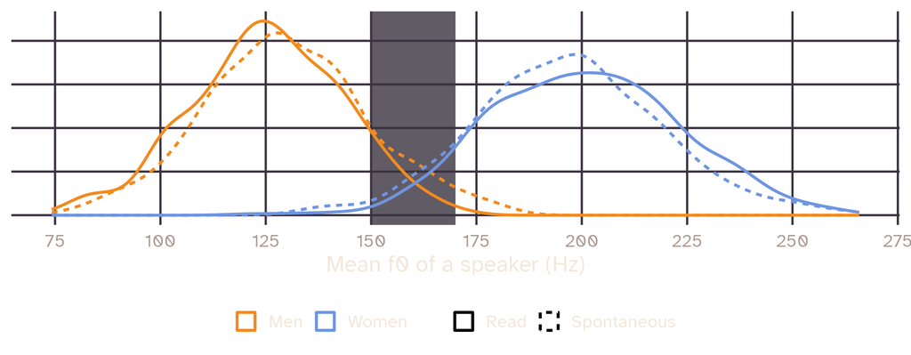

Simulated from the means of 1,000 Swiss German speakers (Hedegard et al., 2023). Shaded: 150–170 Hz, where men and women overlap.

## f0 is not fixed

- A man robbed a petrol station on camera: his mean f0 was 228 Hz. After his arrest, his normal f0 was 140 Hz (Boss, 1996)
- Health, intoxication, stress and emotion all change f0, and average f0 also differs between languages: Japanese women typically speak with higher f0 than American women

## Regional background

How precisely a speaker can be located depends on how much regional variation the language has, how mobile its speakers are, and how much research on that variation exists.

The UK, Germany, Switzerland, France, the Netherlands and the US have long traditions of dialectology. The classic British source is the Survey of English Dialects (SED): over 300 localities, more than a thousand questions, collected mainly in the 1950s.

## FOOT and STRUT

- In much of northern England, FOOT and STRUT have the same vowel: *look* and *luck* sound the same
- In the south, they are different (the FOOT–STRUT split)
- The SED shows the divide as it was in the 1950s, mostly from older rural men, often one speaker per place
- Newer data from the English Dialects App (2016) suggest that the northern pattern is receding

## A moving boundary

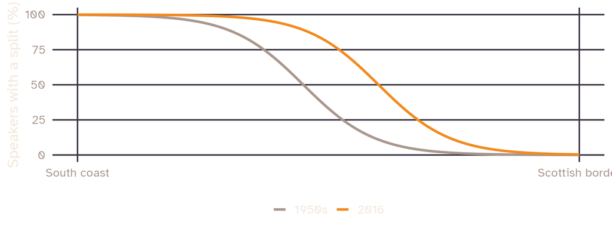

Simulated, to show the trend: the split spreads north, so a 1950s map can point an analyst in the wrong direction.

## How good are experts?

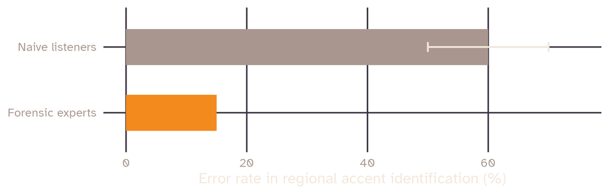

15 German experts, 20 one-minute samples (Köster et al., 2012). Naive listeners: about 50–70% in other studies. Some experts took about a minute per sample, others about an hour.

## Automatic accent recognition

- Most profiling is still done by humans, with auditory and acoustic analysis
- Automatic systems are improving, but need plenty of good-quality speech: some need at least three minutes per speaker, while case recordings are often short and noisy

In practice, analysts usually report a broad area (“northern England”), narrowed only when specific features allow it. In Australia or New Zealand, there is little regional variation to work with.

## Social background

- The UK has a strong tradition of class differences in speech, though weaker than a few decades ago
- The US shows class differences too, but less than the UK
- Norway and German-speaking Switzerland: much regional, less social variation
- Australia and New Zealand: social variation, little regional variation

## Labov’s department stores

- New York City, early 1960s: Saks (upper-class customers), Macy’s (middle class), S. Klein (working class)
- Labov asked staff where to find an item he knew was on the fourth floor
- Then he pretended not to hear, to get a careful repetition of “fourth floor”
- He noted whether each /r/ was pronounced

## Labov’s department stores

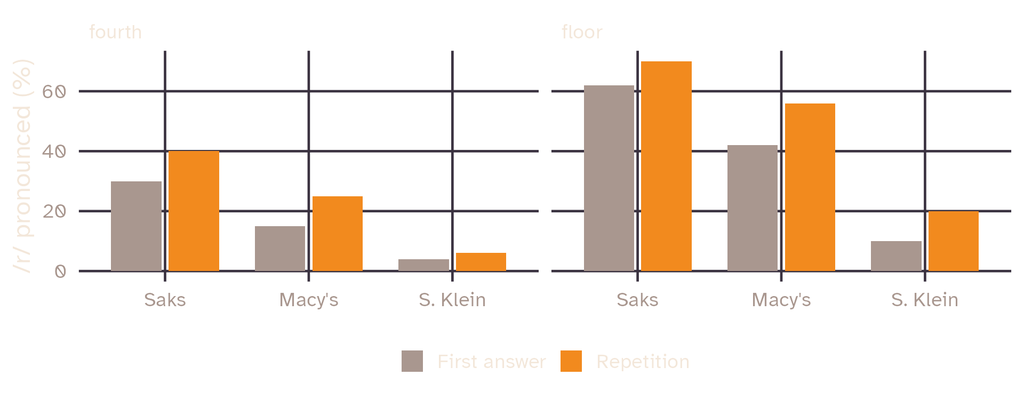

Simulated percentages showing the pattern Labov found: more /r/ in the upper-class store, in careful repetitions, and in *floor* than in *fourth*.

## Which language?

- Not always obvious, especially for less widely known languages, or when speakers switch between languages
- Experts often work with a native-speaker consultant
- Many terrorism cases in the early 2000s were first assumed to involve Arabic. Linguists found they were more often in Pashto, Sylheti or Urdu

## First and second language speakers

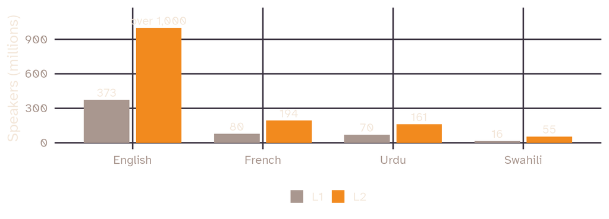

Ethnologue (2022) figures, as reported in Leemann et al. (2024). An L2 speaker on a forensic recording is not surprising.

## From the L2 back to the L1

- Stereotypical transfer is easy to spot: French and German speakers often say s z for English /θ ð/
- In the other direction, English speakers struggle with uvular [ʁ] in German and French, or trilled /r/ in Spanish and Arabic
- Beyond stereotypes, identifying the L1 is much harder
- And even then, the L1 may say little about origin: Arabic is an official language in more than 20 countries

## Speaking style

- Read speech suggests a prepared text, and possibly a planned crime
- Spontaneous speech is more variable and more reduced, with false starts, repetitions, filled pauses and discourse markers
- The Yorkshire Ripper tape: slow, long silent pauses, no disfluencies. It was read
- It was made of four separate recordings, and the music at the end had been on the cassette before the message: a sign of planning (French et al., 2006)

## Environment, time and date

- Background sounds can place a speaker: station announcements, church bells, traffic, trams
- In a German case, an expert heard young birds being fed. An ornithologist helped establish the time of day and the location
- Indoors or outdoors? The reflections of sound off walls can even help reconstruct the room (“roomprints”)

## Electrical network frequency

- Mains electricity leaves a faint hum on many recordings (nominally 50 Hz in Europe)
- Its exact frequency drifts randomly over time, in the same way across a whole grid. Matched against a reference log, it can show when a recording was made, and whether it was edited

## Electrical network frequency

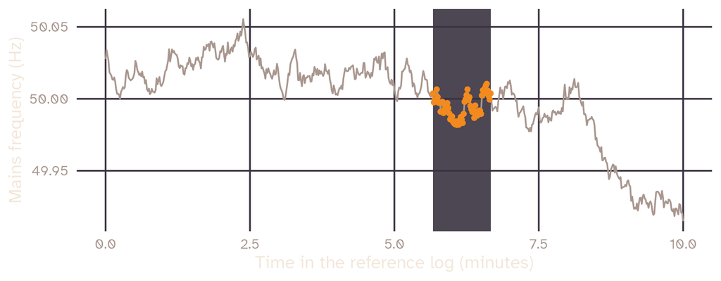

Simulated. Grey: the grid’s reference log. Orange: the hum extracted from a one-minute recording, which matches only one stretch of the log.

# Handle with care

`Did you know:` in red deer, the voice really does reveal size. The lowest formants of a stag’s roar go down with body weight and age, while f0 does not track weight in adult stags. In humans, the link between voice and body size is weak.

*Source: Reby & McComb (2003), Animal Behaviour*

## Speech disorders

- Rare in casework, but very diagnostic when they occur
- Phoneticians consult speech pathologists to classify them
- Disorders can have physical, neuro-motor or functional causes, and each leaves different traces
- A treated speaker may even be on record with a clinic

## Alcohol

- Alcohol affects fine motor control. Apical consonants suffer: *check* [tʃɛk] can become [ʃɛk] (deaffrication)
- f0 usually rises, speaking rate slows, disfluencies increase
- But effects depend on the amount and on mood: one drinker becomes slow and monotonous, another lively and high-pitched

## Other drugs

- Cannabis: more variable voice onset time, flatter f0
- Stimulants: more fluent and talkative, shorter pauses
- LSD: semantic errors rather than disfluency (*butterfly* for a bee)
- Opioids: effects similar to depressants

The conundrum: we usually do not know how the person normally speaks. In 1989, the radio speech of the captain of the *Exxon Valdez* was analysed for intoxication, with inconclusive results.

## Age

- Some differences are obvious: a five-year-old and a fifty-year-old
- But no cue tracks age neatly across the lifespan, and ageing differs between individuals
- Men: f0 drops at puberty, falls until about 40, stays stable until about 60, then rises slightly
- Women: f0 drops at puberty and again after menopause
- f0 also changes over the day: many people are lower in the morning

## Age

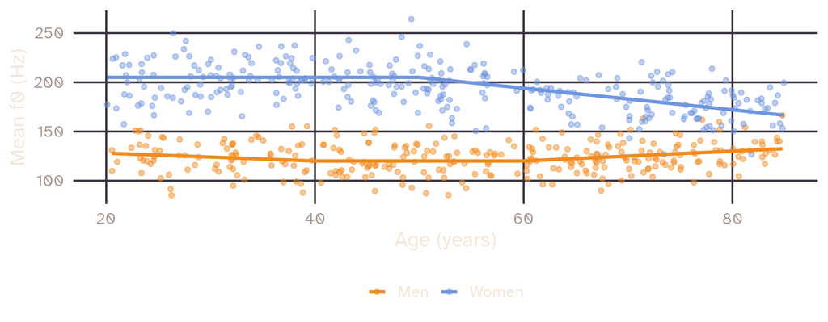

Simulated speakers. The trends are real, but a man at 120 Hz could be 25 or 75. Humans and automatic systems typically err by about ±10 years.

## Height, weight and faces

- A heavyweight boxer and a jockey: who has the lower voice? Most people say the boxer. In reality, voice and body size are only weakly correlated
- Reliable reports do not estimate height or weight
- AI systems such as *Speech2Face* reconstruct a face from speech, and estimate age, gender and ethnicity fairly well (Oh et al., 2019)
- But they are opaque: we cannot check which features drove a decision. Of limited forensic use

## Lies and emotions

- Listeners and automatic systems cannot detect lies above chance
- We read emotions from voices fairly well in everyday life, but the cues are not universal and vary by language and community
- “Voice stress analysis” and “layered voice analysis” are sold to police forces, insurers and airports. Independent research finds them at chance level

Forensic phoneticians do not regard these systems as having any validity.

## Discussion

Independent studies put voice stress analysers at chance level, yet police forces, insurers and airports keep buying them.

- Why might an organisation pay for a tool that does not work?
- A police officer asks you to run such a system on a suspect’s interview “just as a guide”. How would you answer?

# Disguise and spoofing

`Did you know:` red deer stags have a descended larynx, like adult humans. When roaring, they pull it down even further, to the sternum. The longer vocal tract lowers their formants and makes them sound larger.

*Source: Fitch & Reby (2001), Proceedings of the Royal Society B*

## Voice disguise

- A deliberate attempt to change one’s voice to hide one’s identity
- Most common in blackmail and kidnapping. The BKA estimates it occurs in about 15–25% of profiling and speaker comparison cases
- Electronic voice changers are easy to get, but hardly ever used in real cases
- Common methods: raising pitch, whispering, a nasal voice, a pen between the teeth, a fake accent, covering the face

## Covering the face

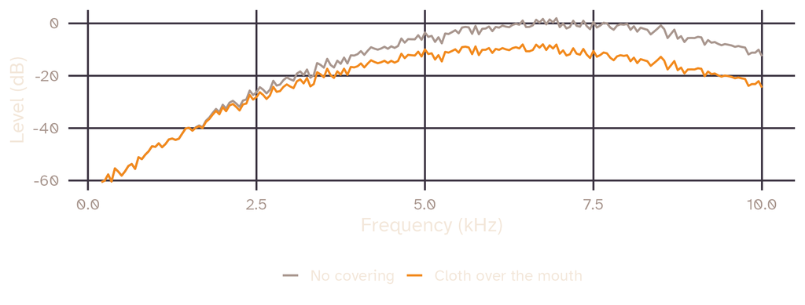

Simulated spectrum of [s]. Cloth damps the high frequencies where much of a fricative’s energy lies. Face masks do the same.

## Does disguise work?

- Often, yes. Whispering lowers identification rates in voice line-ups (Orchard & Yarmey, 1995)
- Faking another accent can bring identification close to chance
- But imitation is hard to sustain: the longer the recording, the more slips
- Real variation is systematic; an imitator rarely reproduces all of it

In a case one of the book’s authors worked on, a caller kept up a consistent fake foreign accent. But his habit of saying f for /v/ (*very* as [fɛɹi]) came through anyway.

## Spoofing

- In 2019, fraudsters used a deepfake of the voice of a German parent company’s chief executive to get the head of a UK firm to transfer €220,000
- Spoofing will likely reach forensic casework; research on telling fake voices from real ones is under way

## Discussion

In January 2005, a man was arrested at Dover: his British passport, in the name of Christopher Buckingham, used the identity of a baby who died in 1963. He called himself Lord Buckingham and claimed to have been educated at Harrow and Cambridge. The media suspected South African, Australian or Eastern European origins.

- How would you test these hypotheses from his police interview?
- What would you expect from a Harrow and Cambridge accent?

## What the experts found

- Mostly standard southern British English, but some postvocalic /r/, yod-dropping, and *Buckingham* with a full final syllable: signs of American English
- Not Australian or South African English (neither is rhotic); no traces of an Eastern European L1
- Some features fitted neither British nor American English, and the team struggled to agree
- His family recognised his photo, and fingerprints confirmed it: he was Charles Stopford, an American from Florida

## Exercise

For the practical sessions (book activity 3A):

- Listen to about two minutes of a speaker from an online dialect archive
- Build a simple profile: where from? how old? education? read or spontaneous?
- Back every claim with the features you heard

## Summary

- A profile narrows down suspects when there is a recording but no suspect
- Key information: sex, regional and social background, language and L2, speaking style, environment
- Dialect maps date quickly; experts combine them with fresh data and experience
- Drugs and disorders can be assessed with caution; age, body size and lying need strong caution
- Disguise is common and often effective, but hard to sustain
- In the Yorkshire Ripper case, an accurate profile still misled the investigation, because of a wrong assumption about who was speaking

## References

- Boss, D. (1996). The problem of F0 and real-life speaker identification: A case study. *Forensic Linguistics*, 3(1), 155–159. https://doi.org/10.1558/ijsll.v3i1.155
- French, P., Harrison, P., & Windsor Lewis, J. (2006). R v John Samuel Humble: The Yorkshire Ripper hoaxer trial. *International Journal of Speech, Language and the Law*, 13(2), 255–273. https://doi.org/10.1558/ijsll.2006.13.2.255
- Hedegard, H., Fröhlich, A., Tomaschek, F., Steiner, C., & Leemann, A. (2023). Filling the population statistics gap: Swiss German reference data on F0 and speech tempo for forensic contexts. *Proceedings of Interspeech 2023*, 2558–2562. https://doi.org/10.21437/Interspeech.2023-1042
- Köster, O., Kehrein, R., Masthoff, K., & Boubaker, Y. H. (2012). The tell-tale accent: Identification of regionally marked speech in German telephone conversations by forensic phoneticians. *International Journal of Speech, Language and the Law*, 19(1), 51–71. https://doi.org/10.1558/ijsll.v19i1.51

## References

- Labov, W. (1966). *The social stratification of English in New York City*. Center for Applied Linguistics, Washington, DC.
- Leemann, A., Perkins, R., Sullivan Buker, G., & Foulkes, P. (2024). *An Introduction to Forensic Phonetics and Forensic Linguistics*. Routledge. Chapter 3.
- Oh, T.-H., Dekel, T., Kim, C., Mosseri, I., Freeman, W. T., Rubinstein, M., & Matusik, W. (2019). Speech2Face: Learning the face behind a voice. *Proceedings of the IEEE/CVF Conference on Computer Vision and Pattern Recognition*, 7539–7548. https://doi.org/10.1109/CVPR.2019.00772
- Orchard, T. L., & Yarmey, A. D. (1995). The effects of whispers, voice-sample duration, and voice distinctiveness on criminal speaker identification. *Applied Cognitive Psychology*, 9(3), 249–260.

## Sources of the animal facts

- Charlton, B. D., Reby, D., & McComb, K. (2007). Female red deer prefer the roars of larger males. *Biology Letters*, 3(4), 382–385. https://doi.org/10.1098/rsbl.2007.0244
- Fitch, W. T., & Reby, D. (2001). The descended larynx is not uniquely human. *Proceedings of the Royal Society B*, 268(1477), 1669–1675. https://doi.org/10.1098/rspb.2001.1704
- Reby, D., André-Obrecht, R., Galinier, A., Farinas, J., & Cargnelutti, B. (2006). Cepstral coefficients and hidden Markov models reveal idiosyncratic voice characteristics in red deer (*Cervus elaphus*) stags. *Journal of the Acoustical Society of America*, 120, 4080–4089.
- Reby, D., & McComb, K. (2003). Anatomical constraints generate honesty: Acoustic cues to age and weight in the roars of red deer stags. *Animal Behaviour*, 65(3), 519–530. https://doi.org/10.1006/anbe.2003.2078
- Reby, D., McComb, K., Cargnelutti, B., Darwin, C., Fitch, W. T., & Clutton-Brock, T. (2005). Red deer stags use formants as assessment cues during intrasexual agonistic interactions. *Proceedings of the Royal Society B*, 272(1566), 941–947. https://doi.org/10.1098/rspb.2004.2954

## Slides and code

[figure not shown]

These slides

mcanzi.de/ws27_fss/03_speaker_profiling.html

Code and all sessions

github.com/mcanzi/ws27_fss